# PCA Introduction

2022-10-04

```r
knitr::opts_chunk$set(echo = TRUE,message = FALSE,warning = FALSE)
library(readxl)
library(tidyverse)
library(janitor)
library(rgl)
library(car)
library(tidyverse)
library(ggfortify)
library(ggforce)
knitr::knit_hooks$set(webgl = hook_webgl)
cbPalette <- c("#E69F00", "#009E73", "#0072B2", "#CC79A7") # custom color-blind friendly palette
```

You’ll need to run the following code (in the console, *not* in RMarkdown):

```
install.packages("rgl")
install.packages("car")
install.packages("ggfortify")
install.packages("ggforce")
install.packages("MASS")
```

Then run the R script `simulate_data.R` to simulate data for this lab exercise.

```r
source("simulate_data.R")
```

This script created a variable named `X` with 3 plant trait columns: Nitrogen (`Nitrogen`), leaf mass per area (`LMA`), and Water Content (`Water`):

```r
head(X)
```

```
##       Nitrogen      LMA      Water
## [1,] -2.581874 2.013188  1.0491225
## [2,] -2.564213 1.846527 -0.9784840
## [3,] -2.543589 2.025816  0.4579531
## [4,] -2.350622 2.001362  0.5043971
## [5,] -2.299563 1.745605  0.5385042
## [6,] -2.279067 1.715343  1.0045059
```

The data are also stored in a data frame called `dat`, but `dat` also has a column named `Type`, which cateogrizes plants as “Dessert Annual”, “Dessert Perennial”, “Temperate Annual”, or “Temperate Perennial”.

```r
head(dat)
```

```
##    Nitrogen      LMA      Water                Type
## 1 -2.581874 2.013188  1.0491225   Dessert Perennial
## 2 -2.564213 1.846527 -0.9784840 Temperate Perennial
## 3 -2.543589 2.025816  0.4579531   Dessert Perennial
## 4 -2.350622 2.001362  0.5043971   Dessert Perennial
## 5 -2.299563 1.745605  0.5385042   Dessert Perennial
## 6 -2.279067 1.715343  1.0045059   Dessert Perennial
```

Let’s see how the variables are correlated with one another:

```r
cor(X) # r
```

```
##            Nitrogen        LMA      Water
## Nitrogen  1.0000000 -0.9005798 -0.2804210
## LMA      -0.9005798  1.0000000  0.6054723
## Water    -0.2804210  0.6054723  1.0000000
```

```r
cor(X)^2 # r-squared
```

```
##            Nitrogen       LMA      Water
## Nitrogen 1.00000000 0.8110439 0.07863592
## LMA      0.81104391 1.0000000 0.36659670
## Water    0.07863592 0.3665967 1.00000000
```

We see that Nitrogen and LMA are strongly negatively correlated:

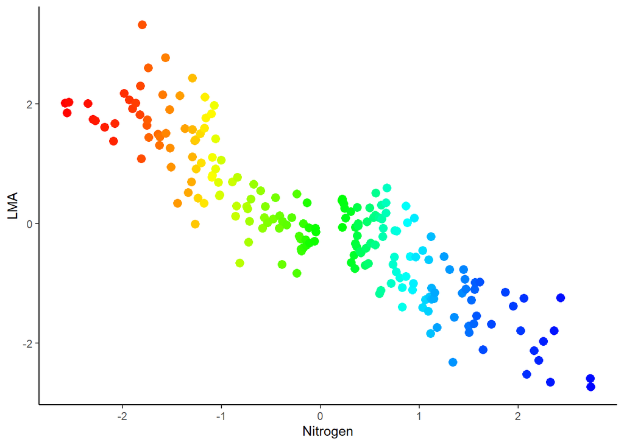

```r
dat %>%
  ggplot(mapping=aes(x = Nitrogen,y = LMA,color = Type)) +
  geom_point(color = cols,size = 3) +
  theme_classic()
```

Next we visualize Nitrogen vs Water, which has a very weak correlation.

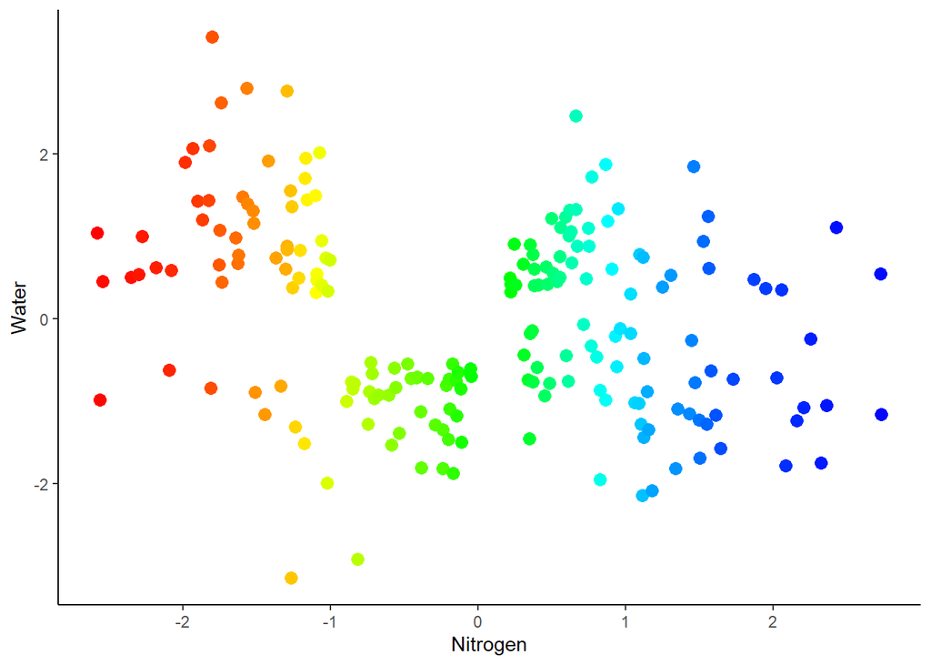

```r
dat %>%
  ggplot(mapping=aes(x = Nitrogen,y = Water,color = Type)) +
  geom_point(color = cols,size = 3) +
  theme_classic()
```

Finally, visualize LMA vs Water Content, which is moderately positively correlated.

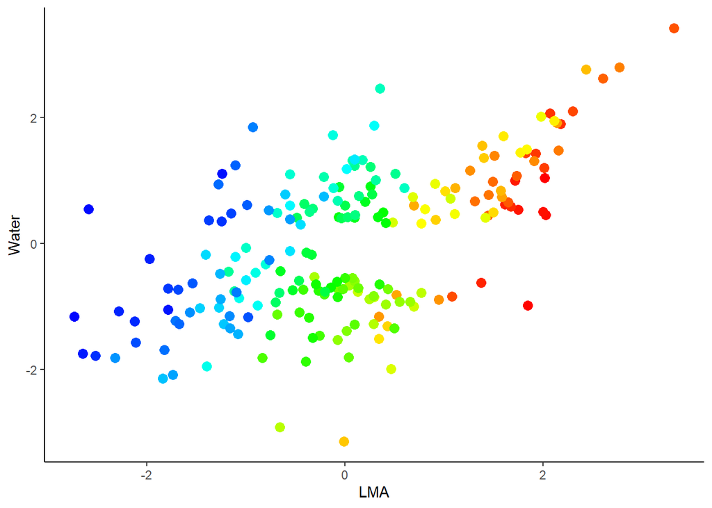

```r
dat %>%
  ggplot(mapping=aes(x = LMA,y = Water,color = Type)) +
  geom_point(color = cols,size = 3) +
  theme_classic()
```

We can view the 3 traits simultaneously in a 3D plot:

```r
scatter3d(x = X[,"Nitrogen"],y = X[,"LMA"],z = X[,"Water"],
          point.col = cols,
          surface.alpha=.00,
          residuals = FALSE,
          sphere.size=1.5,
          fogtype="none",
          xlab = "Nitrogen",
          ylab = "LMA",
          zlab = "Water")
```

[interactive chart not shown]

## Principal Component Analysis (PCA)

Because these traits are correlated, there is redundant information: if you know Nitrogen, you have a pretty good idea of LMA, and if you know LMA, you have a decent idea of Water Content.

In other words, we should be able to summarize an individual plant’s Nitrogen content, LMA, and Water Content with just two variables. Principal component analysis (PCA) is a common way to summarize the traits of several variables with a small number of summary variables.

The following code runs PCA on the data `X`, and then prints the summarized results.

We see the first principal component (PC1) explains nearly three-quarters of the variation in the data! PC2 explains another quarter, and PC3 doesn’t tell us much of anything.

```r
pca <- prcomp(X,center = TRUE,scale. = TRUE)
summary(pca)
```

```
## Importance of components:
##                           PC1    PC2     PC3
## Standard deviation     1.4923 0.8620 0.17302
## Proportion of Variance 0.7423 0.2477 0.00998
## Cumulative Proportion  0.7423 0.9900 1.00000
```

We can also see how correlated (r and R^2) the traits are with each PC:

```r
cor(X,pca$x) # r
```

```
##                 PC1         PC2         PC3
## Nitrogen  0.8820214 -0.45941611  0.10476165
## LMA      -0.9872484  0.09414746  0.12836184
## Water    -0.6887473 -0.72328677 -0.04983397
```

```r
cor(X,pca$x)^2 # r-squared
```

```
##                PC1         PC2         PC3
## Nitrogen 0.7779618 0.211063165 0.010975003
## LMA      0.9746595 0.008863745 0.016476763
## Water    0.4743728 0.523143745 0.002483424
```

Visualize PC1 and PC2 (together they convey almost all of the information about the 3 traits):

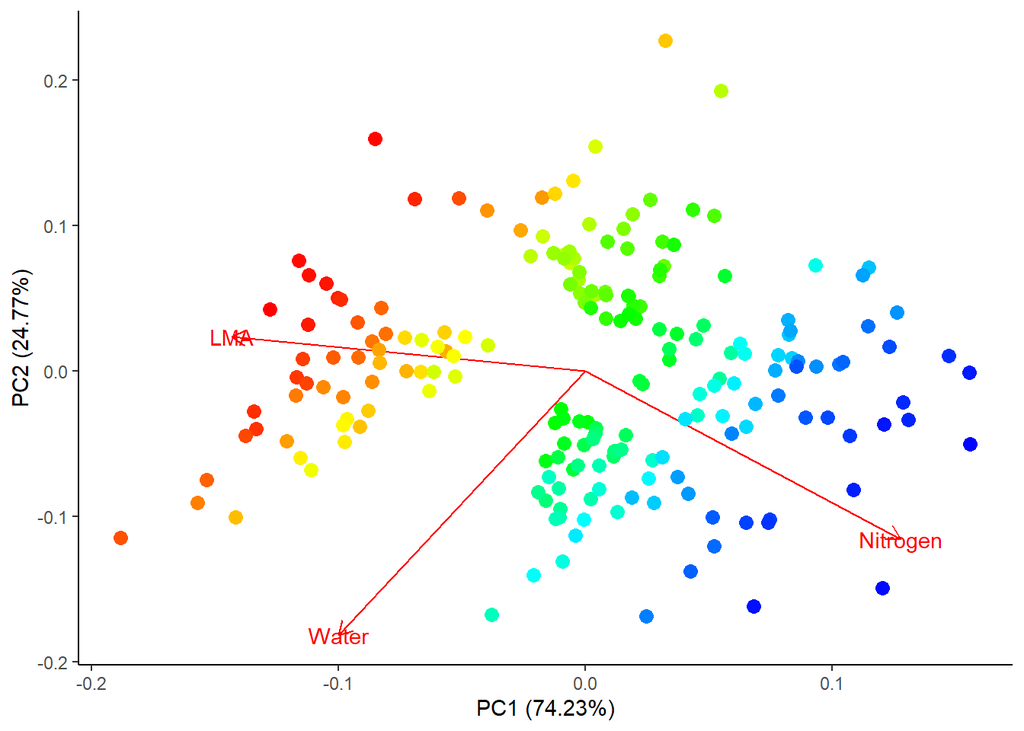

```r
autoplot(object = pca,
         data = dat,
         x = 1,
         y = 2,
         loadings = TRUE,
         loadings.label = TRUE) +
  geom_point(color = cols,size = 3) +
  theme_classic()
```

Visualizing PC1 and PC3 doesn’t provide any new information.

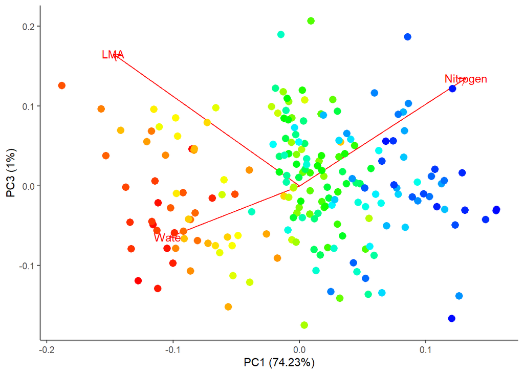

```r
autoplot(object = pca,
         data = dat,
         x = 1,
         y = 3,
         loadings = TRUE,
         loadings.label = TRUE) +
  geom_point(color = cols,size = 3) +
  theme_classic()
```

Nor does visualizing PC2 and PC3.

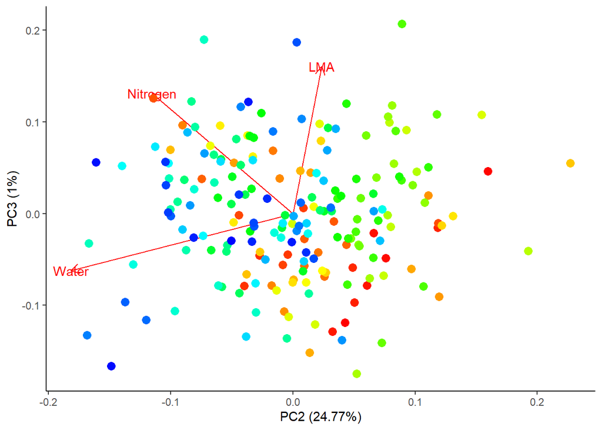

```r
autoplot(object = pca,
         data = dat,
         x = 2,
         y = 3,
         loadings = TRUE,
         loadings.label = TRUE) +
  geom_point(color = cols,size = 3) +
  theme_classic()
```

## Visualing by groups

Now let’s look at the data in context of their habitat. First, Nitrogen vs Water Content:

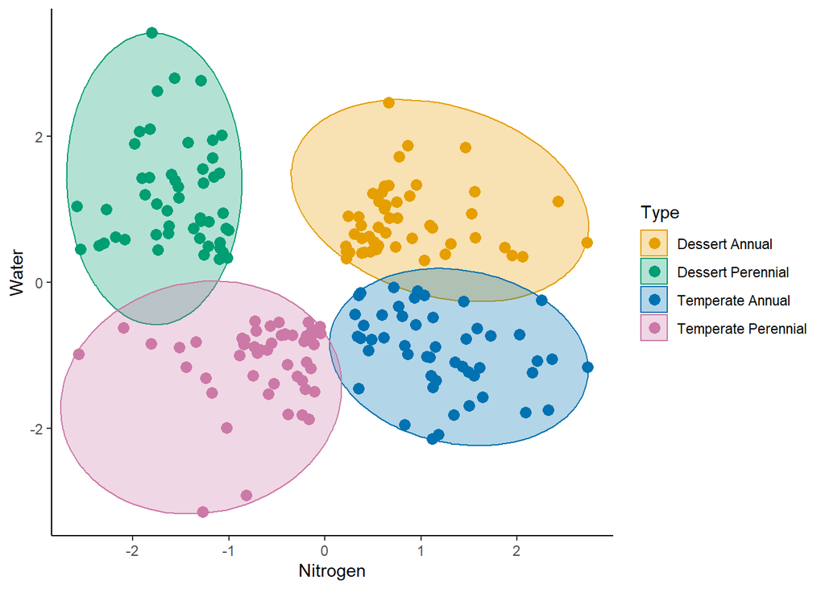

```r
dat %>% ggplot(mapping=aes(x = Nitrogen,y = Water,color = Type)) +   geom_mark_ellipse(mapping = aes(fill = Type),expand = unit(0.5,'mm')) +
  geom_point(mapping = aes(color = Type),size = 3) +
  scale_fill_manual(values = cbPalette) +
  scale_color_manual(values = cbPalette) +
  theme_classic()
```

Nitrogen vs LMA:

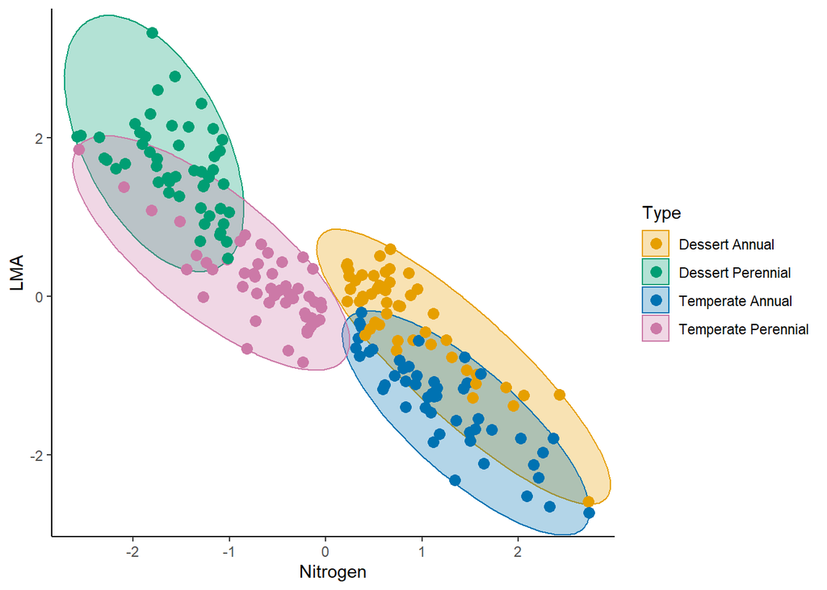

```r
dat %>% ggplot(mapping=aes(x = Nitrogen,y = LMA,color = Type)) +   geom_mark_ellipse(mapping = aes(fill = Type),expand = unit(0.5,'mm')) +
  geom_point(mapping = aes(color = Type),size = 3) +
  scale_fill_manual(values = cbPalette) +
  scale_color_manual(values = cbPalette) +
  theme_classic()
```

LMA vs Water:

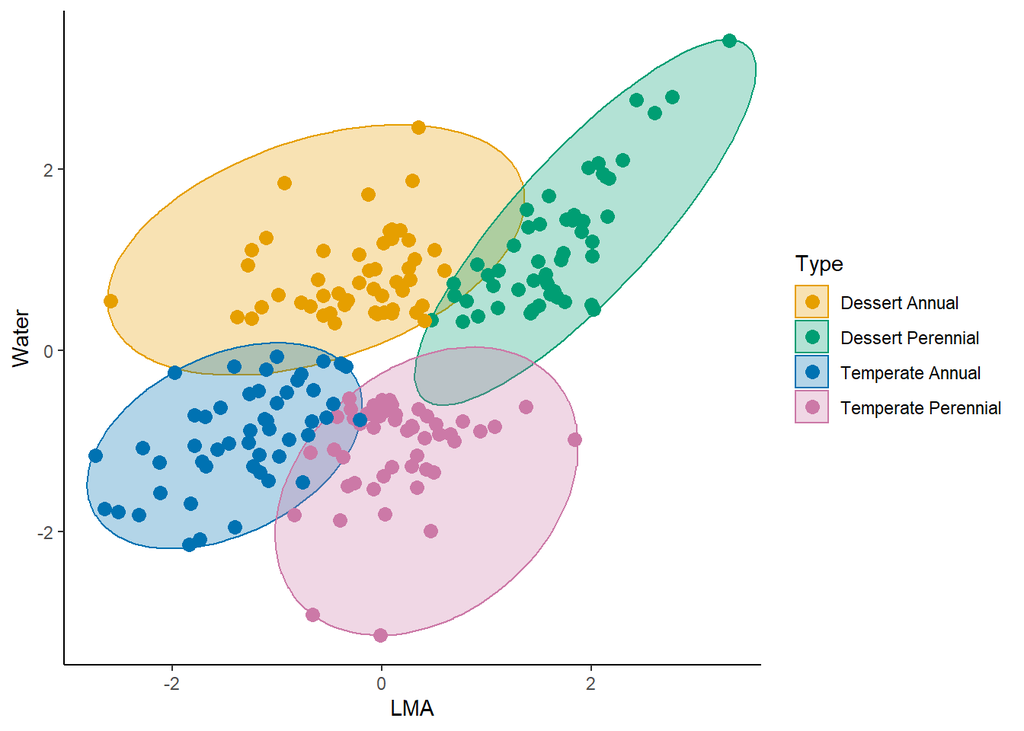

```r
dat %>% ggplot(mapping=aes(x = LMA,y = Water,color = Type)) +   geom_mark_ellipse(mapping = aes(fill = Type),expand = unit(0.5,'mm')) +
  geom_point(mapping = aes(color = Type),size = 3) +
  scale_fill_manual(values = cbPalette) +
  scale_color_manual(values = cbPalette) +
  theme_classic()
```

3D plot:

```r
scatter3d(x = X[,"Nitrogen"],y = X[,"LMA"],z = X[,"Water"],
          point.col = cbPalette[dat$Type],
          surface.alpha=.00,
          residuals = FALSE,
          sphere.size=1.5,
          fogtype="none",
          xlab = "Nitrogen",
          ylab = "LMA",
          zlab = "Water")
```

[interactive chart not shown]

PCA with groups:

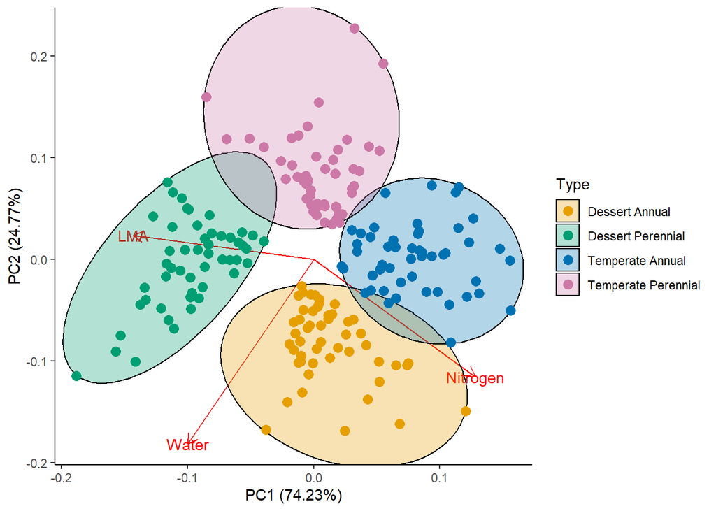

```r
autoplot(pca,data = dat,loadings = TRUE,loadings.label = TRUE) +
  geom_mark_ellipse(mapping = aes(fill = Type),expand = unit(0.5,'mm')) +
  geom_point(mapping = aes(color = Type),size = 3) +
  scale_fill_manual(values = cbPalette) +
  scale_color_manual(values = cbPalette) +
  theme_classic()
```

## Sunflower HPLC Data

```r
library(readxl)
library(tidyverse)
library(janitor)

data <- read_excel("data/Mason_S1.xlsx",
    sheet = "Population_LSMeans", skip = 2) %>% janitor::clean_names()
data$growth_form <- as.factor(data$growth_form)
data <- data %>% filter(complete.cases(data %>% select(starts_with("Compound"))))
data <- data %>% mutate(across(starts_with("Compound"),function(X) X))

compounds <- data %>%
  select(species,growth_form,number_compounds,starts_with("Compound"))
compounds_pca <- prcomp(x = compounds %>% select(where(is_double)),center=TRUE,scale=TRUE)

# which PCs are potentially useful?
round(summary(compounds_pca)$importance,2)
```

```
##                         PC1  PC2  PC3  PC4  PC5  PC6  PC7  PC8  PC9 PC10 PC11
## Standard deviation     2.82 1.67 1.37 1.22 1.16 1.10 0.99 0.96 0.92 0.77 0.72
## Proportion of Variance 0.35 0.12 0.08 0.06 0.06 0.05 0.04 0.04 0.04 0.03 0.02
## Cumulative Proportion  0.35 0.47 0.55 0.61 0.67 0.73 0.77 0.81 0.84 0.87 0.89
##                        PC12 PC13 PC14 PC15 PC16 PC17 PC18 PC19 PC20 PC21 PC22
## Standard deviation     0.67 0.63 0.62 0.53 0.47 0.45 0.41 0.33 0.32 0.26  0.2
## Proportion of Variance 0.02 0.02 0.02 0.01 0.01 0.01 0.01 0.00 0.00 0.00  0.0
## Cumulative Proportion  0.91 0.93 0.95 0.96 0.97 0.98 0.98 0.99 0.99 1.00  1.0
##                        PC23
## Standard deviation     0.17
## Proportion of Variance 0.00
## Cumulative Proportion  1.00
```

```r
# what compounds are most correlated with the most informative PCs?
round(cor(compounds %>% select(where(is_double)),compounds_pca$x)^2,2)[,1:4]
```

```
##                   PC1  PC2  PC3  PC4
## number_compounds 0.00 0.35 0.06 0.13
## compound_76      0.91 0.01 0.00 0.01
## compound_145     0.13 0.37 0.07 0.01
## compound_256     0.28 0.01 0.05 0.11
## compound_368     0.10 0.44 0.01 0.07
## compound_369     0.07 0.49 0.00 0.14
## compound_388     0.05 0.36 0.03 0.04
## compound_424     0.72 0.02 0.01 0.01
## compound_426     0.03 0.01 0.55 0.08
## compound_431     0.78 0.05 0.00 0.03
## compound_434     0.43 0.13 0.17 0.01
## compound_455     0.03 0.18 0.10 0.13
## compound_486     0.57 0.00 0.00 0.00
## compound_491     0.01 0.13 0.13 0.27
## compound_585     0.12 0.01 0.02 0.02
## compound_1135    0.54 0.04 0.09 0.06
## compound_1137    0.10 0.03 0.32 0.05
## compound_1139    0.71 0.12 0.00 0.00
## compound_1141    0.70 0.05 0.07 0.02
## compound_1222    0.42 0.00 0.05 0.08
## compound_1468    0.12 0.01 0.02 0.09
## compound_1553    0.86 0.00 0.01 0.00
## compound_1713    0.26 0.00 0.09 0.13
```

```r
scatter3d(x = data$compound_76,y = data$compound_369,z = data$number_compounds,
          point.col = cbPalette[compounds$growth_form],
          surface.alpha=.00,
          residuals = FALSE,
          sphere.size=1.5,
          fogtype="none",
          xlab = "Compound 76",
          ylab = "Compound 369",
          zlab = "Number Compounds")
```

[output not shown]

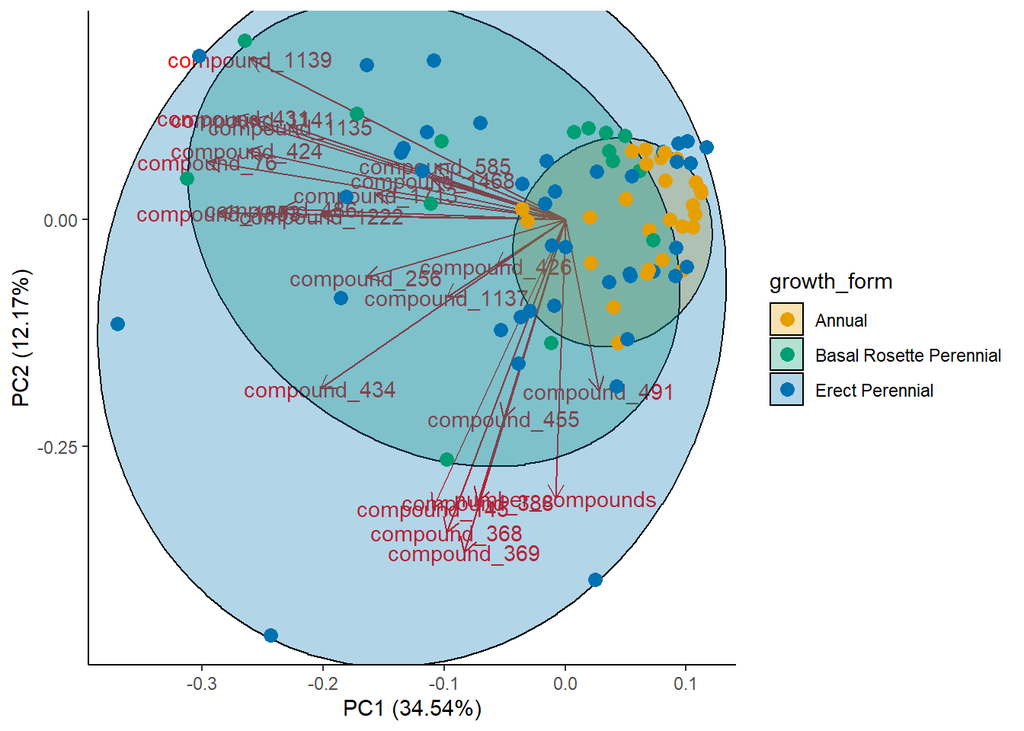

```r
autoplot(compounds_pca,data = compounds,loadings = TRUE,loadings.label = TRUE) +
  geom_mark_ellipse(mapping = aes(fill = growth_form),alpha=.3,expand = unit(0.5,'mm')) +
  geom_point(mapping = aes(color = growth_form),size = 3) +
  scale_fill_manual(values = cbPalette) +
  scale_color_manual(values = cbPalette) +
  theme_classic()
```